# Fitted Exponential Smoothing Model

BETS Package

2017-03-29

## Series Information

```r
library(BETS)
info <- BETS.search(code = ts, view = F)
```

[output not shown]

## Graph

```r
ts = BETS.get(code = ts)
```

```r
library(mFilter)
trend = fitted(hpfilter(ts))


library(dygraphs)
dygraph(cbind(Series = ts, Trend = trend), main = info[1,"Description",]) %>%
  dySeries("Series",color = "royalblue",drawPoints = TRUE) %>%
     dySeries("Trend", strokeWidth = 1, strokePattern = "dashed", color = "red") %>%
        dyRangeSelector(strokeColor = "gray", fillColor = "gray") %>%
          dyAxis("y", label = info[1,"Unit"])
```

[interactive chart not shown]

## Smoothing

You believe the series can be decomposed in a additive fashion (possibly because it seems homoscedastic) and you want the Holt-Winters R algorithm to choose the best alpha value.

In addition, you do not want to model trend and do not think the series has seasonal patterns.

Therefore, this is how we are going to create the model:

```r
model = HoltWinters(ts, beta = beta, gamma = gamma,
                        l.start = l.start, b.start = b.start, s.start = s.start)
```

These are the final parameters:

```r
model
```

```
## Holt-Winters exponential smoothing without trend and without seasonal component.
##
## Call:
## HoltWinters(x = ts, beta = beta, gamma = gamma, l.start = l.start,     b.start = b.start, s.start = s.start)
##
## Smoothing parameters:
##  alpha: 0.854175
##  beta : FALSE
##  gamma: FALSE
##
## Coefficients:
##       [,1]
## a 79.56952
```

## Forecasts

```r
preds = BETS.predict(model,h=n.ahead, main = info[,"Description"], ylab = info[,"Unit"], style = "normal")
```

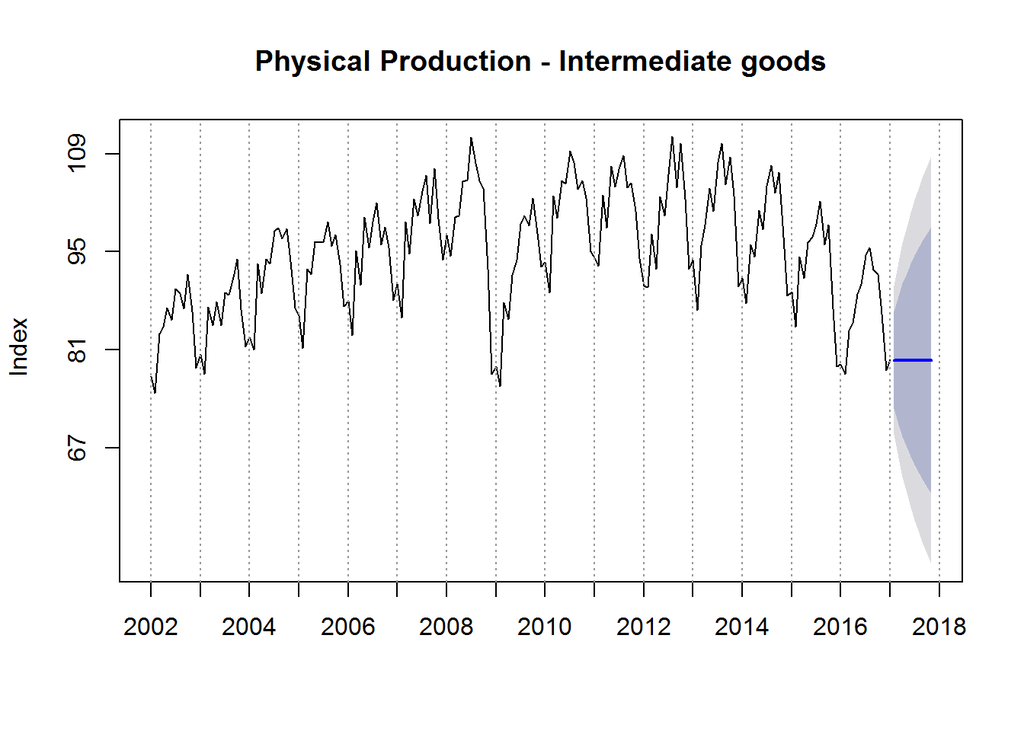

## Model Evaluation

If the model is well-specified, its normalized residuals should not surpass the boundaries of confidence intervals. In addition, it should look like white noise. Here, we plot the normalized residuals with a 95% confidence interval:

```r
std.resid = BETS.std_resid(model, alpha = 0.05)
```

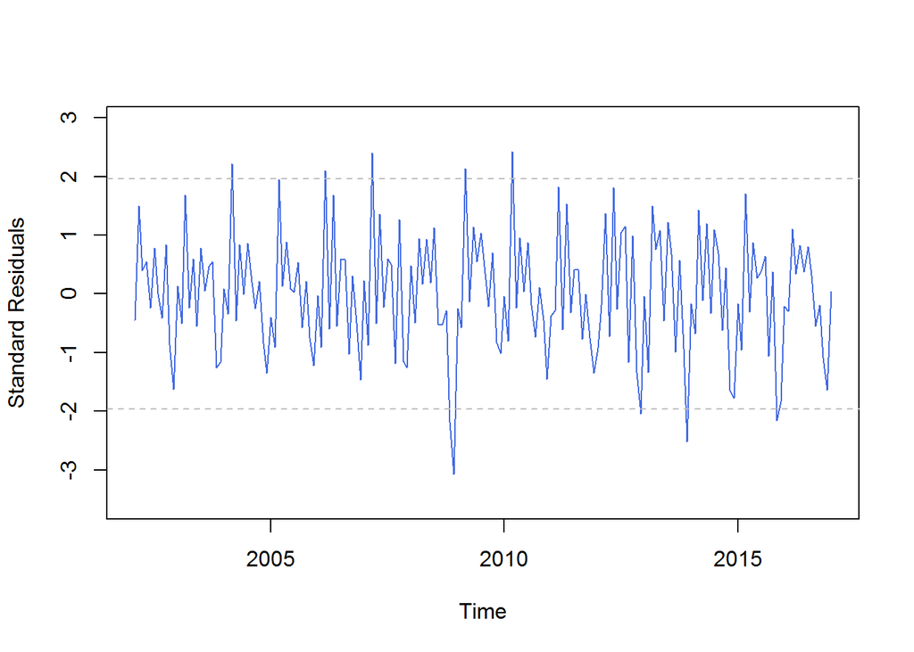

We can use a Ljung-Box test to accept or reject the hypothesis of autocorrelation in the residuals (the forecasting errors):

```r
Box.test(preds$residuals, lag=20, type="Ljung-Box")
```

```
##
##  Box-Ljung test
##
## data:  preds$residuals
## X-squared = 298.8, df = 20, p-value < 2.2e-16
```

Note that the `p.value` is too low, which is an evidence of non-zero autocorrelations in the forecasting errors at lags 1 to 20. It suggests you should change the model specification.

To confirm these results, we can take look at the residuals ACF:

```r
BETS.corrgram(preds$residuals, lag.max = 20, mode = "bartlett", knit = T)
```

[interactive chart not shown]